# Assignment 1 - Linear Regression

### Prajwal Sahu || ME18B114

## Importing Libraries

We'll be using common python libraries like numpy, pandas, seaborn etc.

```python
import pandas as pd
import numpy as np
import matplotlib.pyplot as plt
%matplotlib inline
import seaborn as sns
```

```python
import warnings
warnings.filterwarnings('ignore')
```

## Importing the Data-sets

We have been provided with cancer incidence and death rate for US counties. Each county has a unique FIPS (Federal Information Processing Standards) Code, and the data is sorted by it.

### Data Notes

`FIPS` - Federal Information Processing Standard. Each area has a unique code.

`Incidence_rates` - Cases per 100,000 population per year which are age-adjusted to the 2000 US standard population.

`Mortality Rate` - The measure of number of deaths.

`All_Poverty` - Population For whom income in the past 12 months is below poverty level.

`M_Poverty` - Male Population For whom income in the past 12 months is below poverty level.

`F_Poverty` - Female Population For whom income in the past 12 months is below poverty level.

`Med_Income` - Median household income in the past 12 months

`Med_Income_X` - Median household income in the past 12 months for the X ethnicity ( X - White, Black, Asian, Hispanic etc.).

`All_With` - Population covered by health insurance.

`All_Without` - Population not covered by health insurance.

`M_With, M_Without` - Male population covered and not covered by health insurance respectively.

`F_With, F_Without` - Female population covered and not covered by health insurance respectively.

`Avg_Ann_Deaths` - Average lung cancer mortalities

`Avg_Ann_Incidence` - Average lung cancer incidence rate

## Our Data Set

We have a merged data set containing Income, Poverty and Health Insurance data as well as the Mortality rate in the various counties with FIPS.

```python
mergeddf = pd.read_excel('merged_data.xlsx')
```

```python
mergeddf.head()
```

|  | Unnamed: 0 | State | AreaName | All_Poverty | M_Poverty | F_Poverty | FIPS | Med_Income | Med_Income_White | Med_Income_Black | ... | F_Without | All_With | All_Without | fips_x | Incidence_Rate | Avg_Ann_Incidence | recent_trend | fips_y | Mortality_Rate | Avg_Ann_Deaths |
| --- | --- | --- | --- | --- | --- | --- | --- | --- | --- | --- | --- | --- | --- | --- | --- | --- | --- | --- | --- | --- | --- |
| 0 | 0 | AK | Aleutians East Borough, Alaska | 553 | 334 | 219 | 2013 | 61518.0 | 72639.0 | 31250.0 | ... | 540 | 1442 | 1857 | 2013 | * | 3 or fewer | * | 2013 | * | * |
| 1 | 1 | AK | Aleutians West Census Area, Alaska | 499 | 273 | 226 | 2016 | 84306.0 | 97321.0 | 93750.0 | ... | 564 | 4177 | 1333 | 2016 | * | 3 or fewer | * | 2016 | * | * |
| 2 | 2 | AK | Anchorage Municipality, Alaska | 23914 | 10698 | 13216 | 2020 | 78326.0 | 87235.0 | 50535.0 | ... | 21393 | 243173 | 44638 | 2020 | 61.5 | 131 | stable | 2020 | 47.3 | 96 |
| 3 | 3 | AK | Bethel Census Area, Alaska | 4364 | 2199 | 2165 | 2050 | 51012.0 | 92647.0 | 73661.0 | ... | 1774 | 13023 | 4482 | 2050 | 62.7 | 6 | stable | 2050 | 58.3 | 5 |
| 4 | 4 | AK | Bristol Bay Borough, Alaska | 69 | 33 | 36 | 2060 | 79750.0 | 88000.0 | NaN | ... | 67 | 768 | 191 | 2060 | * | 3 or fewer | * | 2060 | * | * |

5 rows × 26 columns

## Population data

Acquired a data-set from data.world for population estimate in counties in 2015, the year our dataset was collected.

```python
popdf = pd.read_csv('popdata.csv')
popdf.head()
```

|  | SUMLEV | REGION | DIVISION | STATE | COUNTY | STNAME | CTYNAME | POPESTIMATE2015 |
| --- | --- | --- | --- | --- | --- | --- | --- | --- |
| 0 | 40 | 3 | 6 | 1 | 0 | Alabama | Alabama | 4858979 |
| 1 | 50 | 3 | 6 | 1 | 1 | Alabama | Autauga County | 55347 |
| 2 | 50 | 3 | 6 | 1 | 3 | Alabama | Baldwin County | 203709 |
| 3 | 50 | 3 | 6 | 1 | 5 | Alabama | Barbour County | 26489 |
| 4 | 50 | 3 | 6 | 1 | 7 | Alabama | Bibb County | 22583 |

```python
#adding zeroes to adjust for our FIPS

state = popdf.STATE.apply(lambda x: str(x))\

county = popdf.COUNTY.apply(lambda x: str(x))\
                            .str.pad(3, 'left', '0')
```

```python
state
```

```
0        1
1        1
2        1
3        1
4        1
        ..
3188    56
3189    56
3190    56
3191    56
3192    56
Name: STATE, Length: 3193, dtype: object
```

```python
county
```

```
0       000
1       001
2       003
3       005
4       007
       ...
3188    037
3189    039
3190    041
3191    043
3192    045
Name: COUNTY, Length: 3193, dtype: object
```

```python
# Creating a new column for merging
popdf['FIPS']= state + county
popdf
```

|  | SUMLEV | REGION | DIVISION | STATE | COUNTY | STNAME | CTYNAME | POPESTIMATE2015 | FIPS |
| --- | --- | --- | --- | --- | --- | --- | --- | --- | --- |
| 0 | 40 | 3 | 6 | 1 | 0 | Alabama | Alabama | 4858979 | 1000 |
| 1 | 50 | 3 | 6 | 1 | 1 | Alabama | Autauga County | 55347 | 1001 |
| 2 | 50 | 3 | 6 | 1 | 3 | Alabama | Baldwin County | 203709 | 1003 |
| 3 | 50 | 3 | 6 | 1 | 5 | Alabama | Barbour County | 26489 | 1005 |
| 4 | 50 | 3 | 6 | 1 | 7 | Alabama | Bibb County | 22583 | 1007 |
| ... | ... | ... | ... | ... | ... | ... | ... | ... | ... |
| 3188 | 50 | 4 | 8 | 56 | 37 | Wyoming | Sweetwater County | 44626 | 56037 |
| 3189 | 50 | 4 | 8 | 56 | 39 | Wyoming | Teton County | 23125 | 56039 |
| 3190 | 50 | 4 | 8 | 56 | 41 | Wyoming | Uinta County | 20822 | 56041 |
| 3191 | 50 | 4 | 8 | 56 | 43 | Wyoming | Washakie County | 8328 | 56043 |
| 3192 | 50 | 4 | 8 | 56 | 45 | Wyoming | Weston County | 7234 | 56045 |

3193 rows × 9 columns

## Adding Population Estimates to Socio-Economic Data

We merge the 2 dataframes on the FIPS column

```python
popdf['FIPS']=popdf['FIPS'].astype(int)
```

```python
# Checking whether both dfs match

print(sum(pd.Series(mergeddf.FIPS.unique()).isin(popdf.FIPS)), 'matches out of')
print("%d unique values" % len(mergeddf.FIPS.unique()))
```

```
3134 matches out of
3134 unique values
```

```python
# merging

mergeddf = mergeddf.merge(popdf ,right_on = 'FIPS',left_on = 'FIPS')
mergeddf
```

|  | Unnamed: 0 | State | AreaName | All_Poverty | M_Poverty | F_Poverty | FIPS | Med_Income | Med_Income_White | Med_Income_Black | ... | Mortality_Rate | Avg_Ann_Deaths | SUMLEV | REGION | DIVISION | STATE | COUNTY | STNAME | CTYNAME | POPESTIMATE2015 |
| --- | --- | --- | --- | --- | --- | --- | --- | --- | --- | --- | --- | --- | --- | --- | --- | --- | --- | --- | --- | --- | --- |
| 0 | 0 | AK | Aleutians East Borough, Alaska | 553 | 334 | 219 | 2013 | 61518.0 | 72639.0 | 31250.0 | ... | * | * | 50 | 4 | 9 | 2 | 13 | Alaska | Aleutians East Borough | 3341 |
| 1 | 1 | AK | Aleutians West Census Area, Alaska | 499 | 273 | 226 | 2016 | 84306.0 | 97321.0 | 93750.0 | ... | * | * | 50 | 4 | 9 | 2 | 16 | Alaska | Aleutians West Census Area | 5702 |
| 2 | 2 | AK | Anchorage Municipality, Alaska | 23914 | 10698 | 13216 | 2020 | 78326.0 | 87235.0 | 50535.0 | ... | 47.3 | 96 | 50 | 4 | 9 | 2 | 20 | Alaska | Anchorage Municipality | 298695 |
| 3 | 3 | AK | Bethel Census Area, Alaska | 4364 | 2199 | 2165 | 2050 | 51012.0 | 92647.0 | 73661.0 | ... | 58.3 | 5 | 50 | 4 | 9 | 2 | 50 | Alaska | Bethel Census Area | 17946 |
| 4 | 4 | AK | Bristol Bay Borough, Alaska | 69 | 33 | 36 | 2060 | 79750.0 | 88000.0 | NaN | ... | * | * | 50 | 4 | 9 | 2 | 60 | Alaska | Bristol Bay Borough | 892 |
| ... | ... | ... | ... | ... | ... | ... | ... | ... | ... | ... | ... | ... | ... | ... | ... | ... | ... | ... | ... | ... | ... |
| 3129 | 3129 | WY | Sweetwater County, Wyoming | 5058 | 2177 | 2881 | 56037 | 69022.0 | 69333.0 | 23535.0 | ... | 28.4 | 9 | 50 | 4 | 8 | 56 | 37 | Wyoming | Sweetwater County | 44626 |
| 3130 | 3130 | WY | Teton County, Wyoming | 1638 | 1026 | 612 | 56039 | 75325.0 | 77651.0 | NaN | ... | 29.1 | 5 | 50 | 4 | 8 | 56 | 39 | Wyoming | Teton County | 23125 |
| 3131 | 3131 | WY | Uinta County, Wyoming | 2845 | 1453 | 1392 | 56041 | 56569.0 | 56532.0 | NaN | ... | 22.1 | 4 | 50 | 4 | 8 | 56 | 41 | Wyoming | Uinta County | 20822 |
| 3132 | 3132 | WY | Washakie County, Wyoming | 1137 | 489 | 648 | 56043 | 47652.0 | 48110.0 | NaN | ... | 38.2 | 5 | 50 | 4 | 8 | 56 | 43 | Wyoming | Washakie County | 8328 |
| 3133 | 3133 | WY | Weston County, Wyoming | 958 | 354 | 604 | 56045 | 57738.0 | 57842.0 | NaN | ... | 43.5 | 4 | 50 | 4 | 8 | 56 | 45 | Wyoming | Weston County | 7234 |

3134 rows × 34 columns

```python
# dropping extra columns

mergeddf.drop(['SUMLEV','STATE','REGION','DIVISION','COUNTY','STNAME','CTYNAME'], axis=1, inplace=True)
```

# Data Preprocessing

## Checking for Null Values in our dataframe

```python
mergeddf
```

|  | Unnamed: 0 | State | AreaName | All_Poverty | M_Poverty | F_Poverty | FIPS | Med_Income | Med_Income_White | Med_Income_Black | ... | All_With | All_Without | fips_x | Incidence_Rate | Avg_Ann_Incidence | recent_trend | fips_y | Mortality_Rate | Avg_Ann_Deaths | POPESTIMATE2015 |
| --- | --- | --- | --- | --- | --- | --- | --- | --- | --- | --- | --- | --- | --- | --- | --- | --- | --- | --- | --- | --- | --- |
| 0 | 0 | AK | Aleutians East Borough, Alaska | 553 | 334 | 219 | 2013 | 61518.0 | 72639.0 | 31250.0 | ... | 1442 | 1857 | 2013 | * | 3 or fewer | * | 2013 | * | * | 3341 |
| 1 | 1 | AK | Aleutians West Census Area, Alaska | 499 | 273 | 226 | 2016 | 84306.0 | 97321.0 | 93750.0 | ... | 4177 | 1333 | 2016 | * | 3 or fewer | * | 2016 | * | * | 5702 |
| 2 | 2 | AK | Anchorage Municipality, Alaska | 23914 | 10698 | 13216 | 2020 | 78326.0 | 87235.0 | 50535.0 | ... | 243173 | 44638 | 2020 | 61.5 | 131 | stable | 2020 | 47.3 | 96 | 298695 |
| 3 | 3 | AK | Bethel Census Area, Alaska | 4364 | 2199 | 2165 | 2050 | 51012.0 | 92647.0 | 73661.0 | ... | 13023 | 4482 | 2050 | 62.7 | 6 | stable | 2050 | 58.3 | 5 | 17946 |
| 4 | 4 | AK | Bristol Bay Borough, Alaska | 69 | 33 | 36 | 2060 | 79750.0 | 88000.0 | NaN | ... | 768 | 191 | 2060 | * | 3 or fewer | * | 2060 | * | * | 892 |
| ... | ... | ... | ... | ... | ... | ... | ... | ... | ... | ... | ... | ... | ... | ... | ... | ... | ... | ... | ... | ... | ... |
| 3129 | 3129 | WY | Sweetwater County, Wyoming | 5058 | 2177 | 2881 | 56037 | 69022.0 | 69333.0 | 23535.0 | ... | 38491 | 6001 | 56037 | 39.9 | 14 | stable | 56037 | 28.4 | 9 | 44626 |
| 3130 | 3130 | WY | Teton County, Wyoming | 1638 | 1026 | 612 | 56039 | 75325.0 | 77651.0 | NaN | ... | 18503 | 3750 | 56039 | 23.7 | 5 | stable | 56039 | 29.1 | 5 | 23125 |
| 3131 | 3131 | WY | Uinta County, Wyoming | 2845 | 1453 | 1392 | 56041 | 56569.0 | 56532.0 | NaN | ... | 17843 | 2916 | 56041 | 31.7 | 6 | stable | 56041 | 22.1 | 4 | 20822 |
| 3132 | 3132 | WY | Washakie County, Wyoming | 1137 | 489 | 648 | 56043 | 47652.0 | 48110.0 | NaN | ... | 6839 | 1394 | 56043 | 50 | 6 | stable | 56043 | 38.2 | 5 | 8328 |
| 3133 | 3133 | WY | Weston County, Wyoming | 958 | 354 | 604 | 56045 | 57738.0 | 57842.0 | NaN | ... | 6014 | 768 | 56045 | 44.9 | 4 | stable | 56045 | 43.5 | 4 | 7234 |

3134 rows × 27 columns

```python
# missing value count

for col in mergeddf.columns:
    print((col, sum(mergeddf[col].isnull())))
```

```
('Unnamed: 0', 0)
('State', 0)
('AreaName', 0)
('All_Poverty', 0)
('M_Poverty', 0)
('F_Poverty', 0)
('FIPS', 0)
('Med_Income', 1)
('Med_Income_White', 2)
('Med_Income_Black', 1210)
('Med_Income_Nat_Am', 1660)
('Med_Income_Asian', 1757)
('Hispanic', 681)
('M_With', 0)
('M_Without', 0)
('F_With', 0)
('F_Without', 0)
('All_With', 0)
('All_Without', 0)
('fips_x', 0)
('Incidence_Rate', 0)
('Avg_Ann_Incidence', 0)
('recent_trend', 0)
('fips_y', 0)
('Mortality_Rate', 0)
('Avg_Ann_Deaths', 0)
('POPESTIMATE2015', 0)
```

As a significant amount of data is missing, we should drop the income ethnicity data.

```python
mergeddf.drop(['Med_Income_White', 'Med_Income_Black', 'Med_Income_Nat_Am',
             'Med_Income_Asian', 'Hispanic'], axis=1, inplace=True)
```

## Dealing with Strings

We notice some strings in the Data. Let's find out the data types

```python
def get_types(col_name):
    ts = (pd.Series([type(i) for i in mergeddf[col_name]]).value_counts())
    print("%s\n" % feature, ts, "\n", "-"*20)

for feature in mergeddf.columns:
    get_types(feature)
```

```
Unnamed: 0
 <class 'int'>    3134
dtype: int64
 --------------------
State
 <class 'str'>    3134
dtype: int64
 --------------------
AreaName
 <class 'str'>    3134
dtype: int64
 --------------------
All_Poverty
 <class 'int'>    3134
dtype: int64
 --------------------
M_Poverty
 <class 'int'>    3134
dtype: int64
 --------------------
F_Poverty
 <class 'int'>    3134
dtype: int64
 --------------------
FIPS
 <class 'int'>    3134
dtype: int64
 --------------------
Med_Income
 <class 'float'>    3134
dtype: int64
 --------------------
M_With
 <class 'int'>    3134
dtype: int64
 --------------------
M_Without
 <class 'int'>    3134
dtype: int64
 --------------------
```

[output cut: 39 more lines]

```
Mortality_Rate
 <class 'float'>    2539
<class 'str'>       325
<class 'int'>       270
dtype: int64
 --------------------
Avg_Ann_Deaths
 <class 'int'>    2809
<class 'str'>     325
dtype: int64
 --------------------
POPESTIMATE2015
 <class 'int'>    3134
dtype: int64
 --------------------
```

## Cleaning the Data Strings

### Mortality Rate

We need to deal with the columns containing the string *.

Our target variable is the Mortality Rate. Therefore the * values in Mortality rate should be dropped

```python
mergeddf = mergeddf[mergeddf.Mortality_Rate != '*']
```

```python
mergeddf.shape
```

```
(2809, 22)
```

### Med_Income

```python
mergeddf['Med_Income'] = pd.to_numeric(mergeddf.Med_Income)
```

### Incidence Rate

We first find out the various nan values

```python
values = []
for _, j in enumerate(mergeddf.Incidence_Rate):
    try:
        pd.to_numeric(j)
    except:
        values.append(j)

pd.Series(values).value_counts()[:10]
```

```
_         151
__         12
*           5
73.6 #      2
68.2 #      2
71.1 #      2
97 #        1
62.4 #      1
64.9 #      1
69.5 #      1
dtype: int64
```

We will replace string with na.

```python
mergeddf['Incidence_Rate'] = pd.to_numeric(mergeddf.Incidence_Rate, errors='coerce')
```

We fill the empty data with the median.

```python
mergeddf['Incidence_Rate'] = mergeddf.Incidence_Rate.fillna(mergeddf.Incidence_Rate.median())
print(sum(mergeddf.Incidence_Rate.isnull()))
```

```
0
```

### Avg_Ann_Incidence

Following similar procedure as done above in Incidence_Rate

```python
values = []
for _, j in enumerate(mergeddf.Avg_Ann_Incidence):
    try:
        pd.to_numeric(j)
    except:
        values.append(j)

pd.Series(values,dtype = str).value_counts()[:10]
```

```
_             151
__             12
3 or fewer      5
dtype: int64
```

```python
mergeddf['Avg_Ann_Incidence'] = pd.to_numeric(mergeddf.Incidence_Rate, errors='coerce')
mergeddf['Avg_Ann_Incidence'] = mergeddf.Incidence_Rate.fillna(mergeddf.Incidence_Rate.median())
print(sum(mergeddf.Incidence_Rate.isnull()))
```

```
0
```

### Avg_Ann_Deaths

Following similar procedure as done above in Incidence_Rate

```python
values = []
for _, k in enumerate(mergeddf.Avg_Ann_Deaths):
    try:
        pd.to_numeric(k)
    except:
        values.append(k)

pd.Series(values).value_counts()[:10]
```

```
Series([], dtype: int64)
```

```python
mergeddf['Avg_Ann_Deaths'] = pd.to_numeric(mergeddf.Incidence_Rate, errors='coerce')
mergeddf['Avg_Ann_Deaths'] = mergeddf.Incidence_Rate.fillna(mergeddf.Incidence_Rate.median())
print(sum(mergeddf.Incidence_Rate.isnull()))
```

```
0
```

## Dealing with Categorical Variables

We have the recent trend variable which we have to convert to numerical values using dummy variables.

```python
mergeddf
```

|  | Unnamed: 0 | State | AreaName | All_Poverty | M_Poverty | F_Poverty | FIPS | Med_Income | M_With | M_Without | ... | All_With | All_Without | fips_x | Incidence_Rate | Avg_Ann_Incidence | recent_trend | fips_y | Mortality_Rate | Avg_Ann_Deaths | POPESTIMATE2015 |
| --- | --- | --- | --- | --- | --- | --- | --- | --- | --- | --- | --- | --- | --- | --- | --- | --- | --- | --- | --- | --- | --- |
| 2 | 2 | AK | Anchorage Municipality, Alaska | 23914 | 10698 | 13216 | 2020 | 78326.0 | 120747 | 23245 | ... | 243173 | 44638 | 2020 | 61.5 | 61.5 | stable | 2020 | 47.3 | 61.5 | 298695 |
| 3 | 3 | AK | Bethel Census Area, Alaska | 4364 | 2199 | 2165 | 2050 | 51012.0 | 6396 | 2708 | ... | 13023 | 4482 | 2050 | 62.7 | 62.7 | stable | 2050 | 58.3 | 62.7 | 17946 |
| 7 | 7 | AK | Fairbanks North Star Borough, Alaska | 7752 | 3523 | 4229 | 2090 | 71068.0 | 40605 | 6957 | ... | 80815 | 12279 | 2090 | 58.1 | 58.1 | stable | 2090 | 54 | 58.1 | 99631 |
| 9 | 9 | AK | Juneau City and Borough, Alaska | 2110 | 1145 | 965 | 2110 | 85746.0 | 13739 | 2433 | ... | 27321 | 4646 | 2110 | 35.1 | 35.1 | stable | 2110 | 34.4 | 35.1 | 32756 |
| 10 | 10 | AK | Kenai Peninsula Borough, Alaska | 5558 | 2596 | 2962 | 2122 | 63684.0 | 22391 | 6435 | ... | 44059 | 11868 | 2122 | 64.9 | 64.9 | stable | 2122 | 50.1 | 64.9 | 58059 |
| ... | ... | ... | ... | ... | ... | ... | ... | ... | ... | ... | ... | ... | ... | ... | ... | ... | ... | ... | ... | ... | ... |
| 3129 | 3129 | WY | Sweetwater County, Wyoming | 5058 | 2177 | 2881 | 56037 | 69022.0 | 19891 | 3318 | ... | 38491 | 6001 | 56037 | 39.9 | 39.9 | stable | 56037 | 28.4 | 39.9 | 44626 |
| 3130 | 3130 | WY | Teton County, Wyoming | 1638 | 1026 | 612 | 56039 | 75325.0 | 8948 | 2558 | ... | 18503 | 3750 | 56039 | 23.7 | 23.7 | stable | 56039 | 29.1 | 23.7 | 23125 |
| 3131 | 3131 | WY | Uinta County, Wyoming | 2845 | 1453 | 1392 | 56041 | 56569.0 | 9132 | 1413 | ... | 17843 | 2916 | 56041 | 31.7 | 31.7 | stable | 56041 | 22.1 | 31.7 | 20822 |
| 3132 | 3132 | WY | Washakie County, Wyoming | 1137 | 489 | 648 | 56043 | 47652.0 | 3349 | 691 | ... | 6839 | 1394 | 56043 | 50.0 | 50.0 | stable | 56043 | 38.2 | 50.0 | 8328 |
| 3133 | 3133 | WY | Weston County, Wyoming | 958 | 354 | 604 | 56045 | 57738.0 | 2927 | 454 | ... | 6014 | 768 | 56045 | 44.9 | 44.9 | stable | 56045 | 43.5 | 44.9 | 7234 |

2809 rows × 22 columns

```python
# getting value count

mergeddf['recent_trend'].value_counts()
```

```
stable     2382
falling     197
_           151
rising       39
*            28
__           12
Name: recent_trend, dtype: int64
```

We need to replace the * values with stable.

```python
mergeddf.replace({'recent_Trend' : {'*':'stable'}}, inplace=True)
```

Stable trends doesn't affect our model, so we create dummy variables for rising and falling

```python
def f(x, term):
    if x == term:
        return 1
    else:
        return 0
```

```python
mergeddf['rising'] = mergeddf.recent_trend.apply(lambda x: f(x, term='rising'))
```

```python
mergeddf['falling'] = mergeddf.recent_trend.apply(lambda x: f(x, term='falling'))
```

```python
mergeddf
```

|  | Unnamed: 0 | State | AreaName | All_Poverty | M_Poverty | F_Poverty | FIPS | Med_Income | M_With | M_Without | ... | fips_x | Incidence_Rate | Avg_Ann_Incidence | recent_trend | fips_y | Mortality_Rate | Avg_Ann_Deaths | POPESTIMATE2015 | rising | falling |
| --- | --- | --- | --- | --- | --- | --- | --- | --- | --- | --- | --- | --- | --- | --- | --- | --- | --- | --- | --- | --- | --- |
| 2 | 2 | AK | Anchorage Municipality, Alaska | 23914 | 10698 | 13216 | 2020 | 78326.0 | 120747 | 23245 | ... | 2020 | 61.5 | 61.5 | stable | 2020 | 47.3 | 61.5 | 298695 | 0 | 0 |
| 3 | 3 | AK | Bethel Census Area, Alaska | 4364 | 2199 | 2165 | 2050 | 51012.0 | 6396 | 2708 | ... | 2050 | 62.7 | 62.7 | stable | 2050 | 58.3 | 62.7 | 17946 | 0 | 0 |
| 7 | 7 | AK | Fairbanks North Star Borough, Alaska | 7752 | 3523 | 4229 | 2090 | 71068.0 | 40605 | 6957 | ... | 2090 | 58.1 | 58.1 | stable | 2090 | 54 | 58.1 | 99631 | 0 | 0 |
| 9 | 9 | AK | Juneau City and Borough, Alaska | 2110 | 1145 | 965 | 2110 | 85746.0 | 13739 | 2433 | ... | 2110 | 35.1 | 35.1 | stable | 2110 | 34.4 | 35.1 | 32756 | 0 | 0 |
| 10 | 10 | AK | Kenai Peninsula Borough, Alaska | 5558 | 2596 | 2962 | 2122 | 63684.0 | 22391 | 6435 | ... | 2122 | 64.9 | 64.9 | stable | 2122 | 50.1 | 64.9 | 58059 | 0 | 0 |
| ... | ... | ... | ... | ... | ... | ... | ... | ... | ... | ... | ... | ... | ... | ... | ... | ... | ... | ... | ... | ... | ... |
| 3129 | 3129 | WY | Sweetwater County, Wyoming | 5058 | 2177 | 2881 | 56037 | 69022.0 | 19891 | 3318 | ... | 56037 | 39.9 | 39.9 | stable | 56037 | 28.4 | 39.9 | 44626 | 0 | 0 |
| 3130 | 3130 | WY | Teton County, Wyoming | 1638 | 1026 | 612 | 56039 | 75325.0 | 8948 | 2558 | ... | 56039 | 23.7 | 23.7 | stable | 56039 | 29.1 | 23.7 | 23125 | 0 | 0 |
| 3131 | 3131 | WY | Uinta County, Wyoming | 2845 | 1453 | 1392 | 56041 | 56569.0 | 9132 | 1413 | ... | 56041 | 31.7 | 31.7 | stable | 56041 | 22.1 | 31.7 | 20822 | 0 | 0 |
| 3132 | 3132 | WY | Washakie County, Wyoming | 1137 | 489 | 648 | 56043 | 47652.0 | 3349 | 691 | ... | 56043 | 50.0 | 50.0 | stable | 56043 | 38.2 | 50.0 | 8328 | 0 | 0 |
| 3133 | 3133 | WY | Weston County, Wyoming | 958 | 354 | 604 | 56045 | 57738.0 | 2927 | 454 | ... | 56045 | 44.9 | 44.9 | stable | 56045 | 43.5 | 44.9 | 7234 | 0 | 0 |

2809 rows × 24 columns

```python
# original column no longer needed

mergeddf.drop(['recent_trend'],axis=1,inplace = True)
```

Data is cleaned.

## Dropping unnecessary columns

```python
finaldf = mergeddf.drop(['Unnamed: 0','State','AreaName','FIPS','fips_x','fips_y'],axis=1)
```

```python
finaldf.head()
```

|  | All_Poverty | M_Poverty | F_Poverty | Med_Income | M_With | M_Without | F_With | F_Without | All_With | All_Without | Incidence_Rate | Avg_Ann_Incidence | Mortality_Rate | Avg_Ann_Deaths | POPESTIMATE2015 | rising | falling |
| --- | --- | --- | --- | --- | --- | --- | --- | --- | --- | --- | --- | --- | --- | --- | --- | --- | --- |
| 2 | 23914 | 10698 | 13216 | 78326.0 | 120747 | 23245 | 122426 | 21393 | 243173 | 44638 | 61.5 | 61.5 | 47.3 | 61.5 | 298695 | 0 | 0 |
| 3 | 4364 | 2199 | 2165 | 51012.0 | 6396 | 2708 | 6627 | 1774 | 13023 | 4482 | 62.7 | 62.7 | 58.3 | 62.7 | 17946 | 0 | 0 |
| 7 | 7752 | 3523 | 4229 | 71068.0 | 40605 | 6957 | 40210 | 5322 | 80815 | 12279 | 58.1 | 58.1 | 54 | 58.1 | 99631 | 0 | 0 |
| 9 | 2110 | 1145 | 965 | 85746.0 | 13739 | 2433 | 13582 | 2213 | 27321 | 4646 | 35.1 | 35.1 | 34.4 | 35.1 | 32756 | 0 | 0 |
| 10 | 5558 | 2596 | 2962 | 63684.0 | 22391 | 6435 | 21668 | 5433 | 44059 | 11868 | 64.9 | 64.9 | 50.1 | 64.9 | 58059 | 0 | 0 |

## Determining Correlation

We'll check correlation between similar variables to decide which ones to use for our model

### Poverty

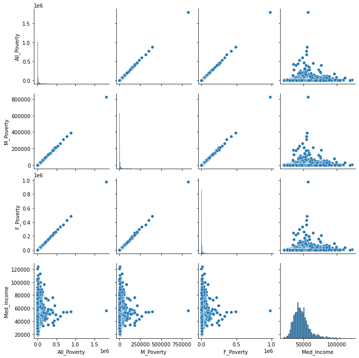

```python
sns.pairplot(finaldf[['All_Poverty','M_Poverty','F_Poverty','Med_Income']])
```

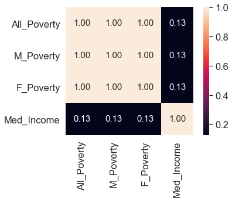

```python
# heatmap for correlation

cols = ['All_Poverty', 'M_Poverty', 'F_Poverty', 'Med_Income']
cm = np.corrcoef(finaldf[['All_Poverty', 'M_Poverty', 'F_Poverty', 'Med_Income']].values.T)
sns.set(font_scale=1.5)
hm = sns.heatmap(cm, cbar=True, annot=True, square=True, fmt='.2f', annot_kws={'size':15},
                 yticklabels=cols, xticklabels=cols)
plt.show()
```

We can drop M_Poverty and F_Poverty as we see very high correlation between the gender related Poverty data.

```python
finaldf = finaldf.drop(['M_Poverty', 'F_Poverty'],axis=1)
```

### Health Insurance

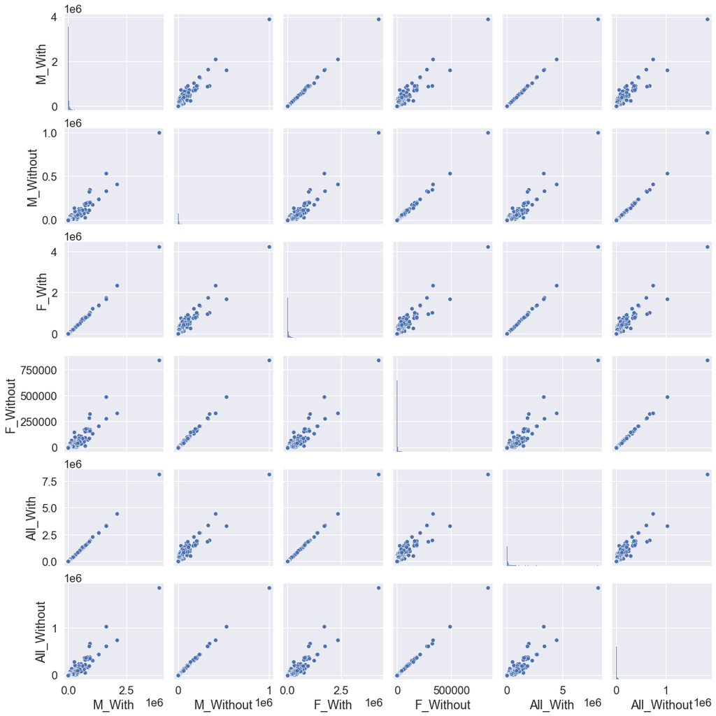

```python
sns.pairplot(finaldf[['M_With','M_Without','F_With','F_Without','All_With','All_Without']])
```

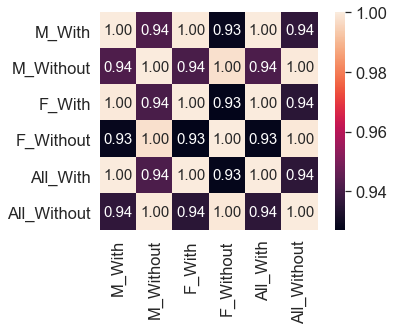

```python
# heatmap for correlation

cols = ['M_With','M_Without','F_With','F_Without','All_With','All_Without']
cm = np.corrcoef(finaldf[['M_With','M_Without','F_With','F_Without','All_With','All_Without']].values.T)
sns.set(font_scale=1.5)
hm = sns.heatmap(cm, cbar=True, annot=True, square=True, fmt='.2f', annot_kws={'size':15},
                 yticklabels=cols, xticklabels=cols)
plt.show()
```

Similar to Poverty, We can drop M_With, M_Without, F_With, F_Without due to high correlation.

```python
finaldf = finaldf.drop(['M_With','M_Without','F_With','F_Without'],axis=1)
```

```python
finaldf.head()
```

|  | All_Poverty | Med_Income | All_With | All_Without | Incidence_Rate | Avg_Ann_Incidence | Mortality_Rate | Avg_Ann_Deaths | POPESTIMATE2015 | rising | falling |
| --- | --- | --- | --- | --- | --- | --- | --- | --- | --- | --- | --- |
| 2 | 23914 | 78326.0 | 243173 | 44638 | 61.5 | 61.5 | 47.3 | 61.5 | 298695 | 0 | 0 |
| 3 | 4364 | 51012.0 | 13023 | 4482 | 62.7 | 62.7 | 58.3 | 62.7 | 17946 | 0 | 0 |
| 7 | 7752 | 71068.0 | 80815 | 12279 | 58.1 | 58.1 | 54 | 58.1 | 99631 | 0 | 0 |
| 9 | 2110 | 85746.0 | 27321 | 4646 | 35.1 | 35.1 | 34.4 | 35.1 | 32756 | 0 | 0 |
| 10 | 5558 | 63684.0 | 44059 | 11868 | 64.9 | 64.9 | 50.1 | 64.9 | 58059 | 0 | 0 |

## Incidence, Death and Incidence Rate

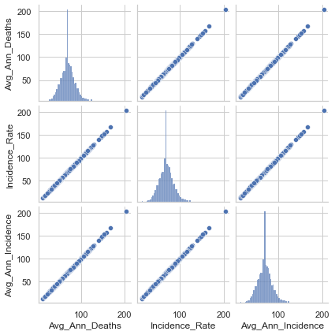

```python
cols = ['Avg_Ann_Deaths','Incidence_Rate','Avg_Ann_Incidence']
sns.set(style='whitegrid', context='notebook')
sns.pairplot(finaldf[cols],size=2)
plt.show()
```

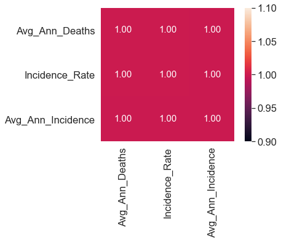

```python
# heatmap for correlation

cols = ['Avg_Ann_Deaths','Incidence_Rate','Avg_Ann_Incidence']
cm = np.corrcoef(finaldf[['Avg_Ann_Deaths','Incidence_Rate','Avg_Ann_Incidence']].values.T)
sns.set(font_scale=1.5)
hm = sns.heatmap(cm, cbar=True, annot=True, square=True, fmt='.2f', annot_kws={'size':15},
                 yticklabels=cols, xticklabels=cols)
plt.show()
```

```python
finaldf = finaldf.drop(['Avg_Ann_Deaths','Avg_Ann_Incidence'],axis=1)
```

## Normalizing Data by Population

We create new columns with Population Normalization for Poverty and Health Insurance Data. We use the Population estimates we acquired.

```python
finaldf
```

|  | All_Poverty | Med_Income | All_With | All_Without | Incidence_Rate | Mortality_Rate | POPESTIMATE2015 | rising | falling |
| --- | --- | --- | --- | --- | --- | --- | --- | --- | --- |
| 2 | 23914 | 78326.0 | 243173 | 44638 | 61.5 | 47.3 | 298695 | 0 | 0 |
| 3 | 4364 | 51012.0 | 13023 | 4482 | 62.7 | 58.3 | 17946 | 0 | 0 |
| 7 | 7752 | 71068.0 | 80815 | 12279 | 58.1 | 54 | 99631 | 0 | 0 |
| 9 | 2110 | 85746.0 | 27321 | 4646 | 35.1 | 34.4 | 32756 | 0 | 0 |
| 10 | 5558 | 63684.0 | 44059 | 11868 | 64.9 | 50.1 | 58059 | 0 | 0 |
| ... | ... | ... | ... | ... | ... | ... | ... | ... | ... |
| 3129 | 5058 | 69022.0 | 38491 | 6001 | 39.9 | 28.4 | 44626 | 0 | 0 |
| 3130 | 1638 | 75325.0 | 18503 | 3750 | 23.7 | 29.1 | 23125 | 0 | 0 |
| 3131 | 2845 | 56569.0 | 17843 | 2916 | 31.7 | 22.1 | 20822 | 0 | 0 |
| 3132 | 1137 | 47652.0 | 6839 | 1394 | 50.0 | 38.2 | 8328 | 0 | 0 |
| 3133 | 958 | 57738.0 | 6014 | 768 | 44.9 | 43.5 | 7234 | 0 | 0 |

2809 rows × 9 columns

```python
for col in ['All_Poverty','All_With', 'All_Without']:

    finaldf[col + "_PN"] = finaldf[col] / finaldf.POPESTIMATE2015 * 10**5
```

```python
finaldf
```

|  | All_Poverty | Med_Income | All_With | All_Without | Incidence_Rate | Mortality_Rate | POPESTIMATE2015 | rising | falling | All_Poverty_PN | All_With_PN | All_Without_PN |
| --- | --- | --- | --- | --- | --- | --- | --- | --- | --- | --- | --- | --- |
| 2 | 23914 | 78326.0 | 243173 | 44638 | 61.5 | 47.3 | 298695 | 0 | 0 | 8006.160130 | 81411.808032 | 14944.341218 |
| 3 | 4364 | 51012.0 | 13023 | 4482 | 62.7 | 58.3 | 17946 | 0 | 0 | 24317.396634 | 72567.703109 | 24974.924774 |
| 7 | 7752 | 71068.0 | 80815 | 12279 | 58.1 | 54 | 99631 | 0 | 0 | 7780.710823 | 81114.311811 | 12324.477321 |
| 9 | 2110 | 85746.0 | 27321 | 4646 | 35.1 | 34.4 | 32756 | 0 | 0 | 6441.567957 | 83407.619978 | 14183.661009 |
| 10 | 5558 | 63684.0 | 44059 | 11868 | 64.9 | 50.1 | 58059 | 0 | 0 | 9573.020548 | 75886.598116 | 20441.275254 |
| ... | ... | ... | ... | ... | ... | ... | ... | ... | ... | ... | ... | ... |
| 3129 | 5058 | 69022.0 | 38491 | 6001 | 39.9 | 28.4 | 44626 | 0 | 0 | 11334.199794 | 86252.408910 | 13447.317707 |
| 3130 | 1638 | 75325.0 | 18503 | 3750 | 23.7 | 29.1 | 23125 | 0 | 0 | 7083.243243 | 80012.972973 | 16216.216216 |
| 3131 | 2845 | 56569.0 | 17843 | 2916 | 31.7 | 22.1 | 20822 | 0 | 0 | 13663.432908 | 85693.017001 | 14004.418404 |
| 3132 | 1137 | 47652.0 | 6839 | 1394 | 50.0 | 38.2 | 8328 | 0 | 0 | 13652.737752 | 82120.557157 | 16738.712776 |
| 3133 | 958 | 57738.0 | 6014 | 768 | 44.9 | 43.5 | 7234 | 0 | 0 | 13243.019077 | 83135.194913 | 10616.533038 |

2809 rows × 12 columns

Dropping the non-normalized columns

```python
finaldf = finaldf.drop(['All_Poverty','All_With','All_Without'],axis=1)
```

```python
finaldf
```

|  | Med_Income | Incidence_Rate | Mortality_Rate | POPESTIMATE2015 | rising | falling | All_Poverty_PN | All_With_PN | All_Without_PN |
| --- | --- | --- | --- | --- | --- | --- | --- | --- | --- |
| 2 | 78326.0 | 61.5 | 47.3 | 298695 | 0 | 0 | 8006.160130 | 81411.808032 | 14944.341218 |
| 3 | 51012.0 | 62.7 | 58.3 | 17946 | 0 | 0 | 24317.396634 | 72567.703109 | 24974.924774 |
| 7 | 71068.0 | 58.1 | 54 | 99631 | 0 | 0 | 7780.710823 | 81114.311811 | 12324.477321 |
| 9 | 85746.0 | 35.1 | 34.4 | 32756 | 0 | 0 | 6441.567957 | 83407.619978 | 14183.661009 |
| 10 | 63684.0 | 64.9 | 50.1 | 58059 | 0 | 0 | 9573.020548 | 75886.598116 | 20441.275254 |
| ... | ... | ... | ... | ... | ... | ... | ... | ... | ... |
| 3129 | 69022.0 | 39.9 | 28.4 | 44626 | 0 | 0 | 11334.199794 | 86252.408910 | 13447.317707 |
| 3130 | 75325.0 | 23.7 | 29.1 | 23125 | 0 | 0 | 7083.243243 | 80012.972973 | 16216.216216 |
| 3131 | 56569.0 | 31.7 | 22.1 | 20822 | 0 | 0 | 13663.432908 | 85693.017001 | 14004.418404 |
| 3132 | 47652.0 | 50.0 | 38.2 | 8328 | 0 | 0 | 13652.737752 | 82120.557157 | 16738.712776 |
| 3133 | 57738.0 | 44.9 | 43.5 | 7234 | 0 | 0 | 13243.019077 | 83135.194913 | 10616.533038 |

2809 rows × 9 columns

## Visualising Final Data and Exploratory Analysis

```python
finaldf.describe()
```

|  | Med_Income | Incidence_Rate | POPESTIMATE2015 | rising | falling | All_Poverty_PN | All_With_PN | All_Without_PN |
| --- | --- | --- | --- | --- | --- | --- | --- | --- |
| count | 2809.000000 | 2809.000000 | 2.809000e+03 | 2809.000000 | 2809.000000 | 2809.000000 | 2809.000000 | 2809.000000 |
| mean | 46812.890352 | 70.174404 | 1.139303e+05 | 0.013884 | 0.070132 | 16251.736718 | 84378.672391 | 12764.080180 |
| std | 12420.272665 | 17.008618 | 3.463393e+05 | 0.117030 | 0.255414 | 6119.212012 | 6366.722687 | 4806.067161 |
| min | 19328.000000 | 13.500000 | 2.302000e+03 | 0.000000 | 0.000000 | 2598.617910 | 43907.376945 | 2160.560786 |
| 25% | 38698.000000 | 59.800000 | 1.484400e+04 | 0.000000 | 0.000000 | 11867.195818 | 81079.218680 | 9130.495367 |
| 50% | 45048.000000 | 69.700000 | 3.118300e+04 | 0.000000 | 0.000000 | 15640.873409 | 85312.854212 | 12380.351710 |
| 75% | 52149.000000 | 79.100000 | 7.916100e+04 | 0.000000 | 0.000000 | 19775.868774 | 88916.649316 | 15634.684614 |
| max | 123453.000000 | 203.700000 | 1.017029e+07 | 1.000000 | 1.000000 | 46489.942720 | 96720.594666 | 41562.524157 |

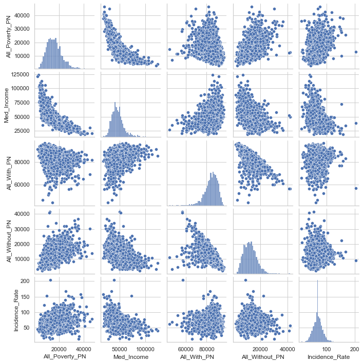

```python
cols = ['All_Poverty_PN', 'Med_Income', 'All_With_PN', 'All_Without_PN',
                'Incidence_Rate']
sns.set(style='whitegrid', context='notebook')
sns.pairplot(finaldf[cols],height=2)
plt.show()
```

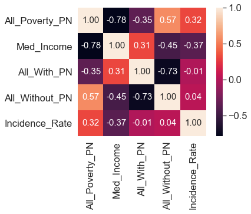

```python
cm = np.corrcoef(finaldf[cols].values.T)
sns.set(font_scale=1.5)
hm = sns.heatmap(cm, cbar=True, annot=True, square=True, fmt='.2f', annot_kws={'size':15},
                 yticklabels=cols, xticklabels=cols)
plt.show()
```

## Income Trends with Incidence Rate

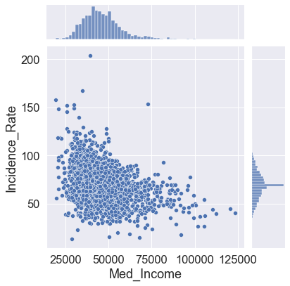

```python
sns.jointplot(x='Med_Income',y='Incidence_Rate' ,data=finaldf)
```

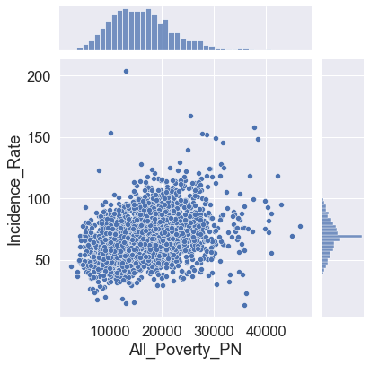

```python
sns.jointplot(x='All_Poverty_PN',y='Incidence_Rate' ,data=finaldf)
```

There is clear visual evidence that lower income groups have higher incidence rate.

## Trends with Mortality Rate

We use scatterplots for our columns with mortality rate to visualize trends.

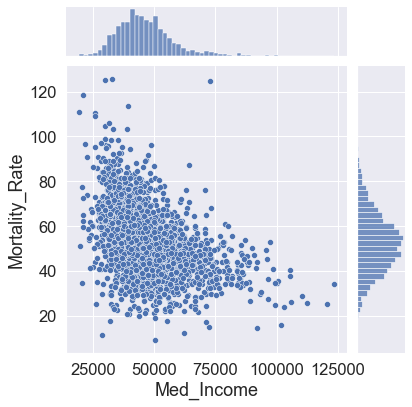

```python
sns.jointplot(x='Med_Income',y='Mortality_Rate' ,data=finaldf)
```

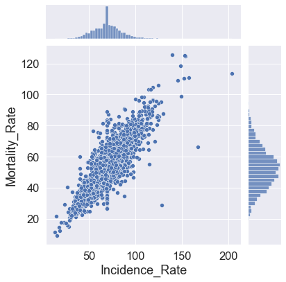

```python
sns.jointplot(x='Incidence_Rate',y='Mortality_Rate',data=finaldf)
```

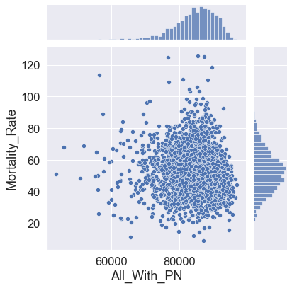

```python
sns.jointplot(x='All_With_PN',y='Mortality_Rate',data=finaldf)
```

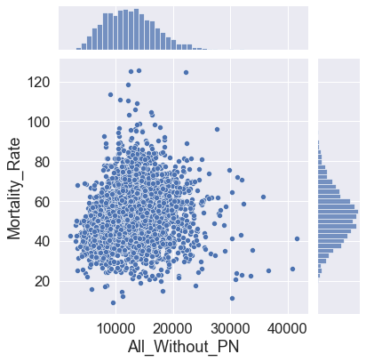

```python
sns.jointplot(x='All_Without_PN',y='Mortality_Rate',data=finaldf)
```

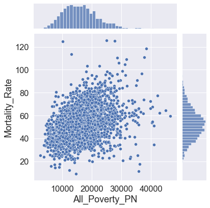

```python
sns.jointplot(x='All_Poverty_PN',y='Mortality_Rate',data=finaldf)
```

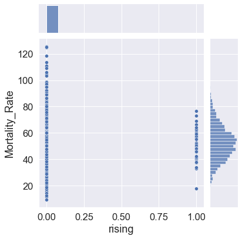

```python
sns.jointplot(x='rising',y='Mortality_Rate',data=finaldf)
```

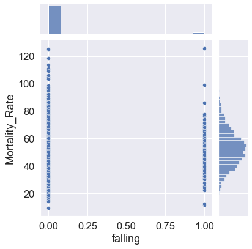

```python
sns.jointplot(x='falling',y='Mortality_Rate',data=finaldf)
```

# Model Building

```python
y = finaldf['Mortality_Rate']
X = finaldf[['All_Poverty_PN', 'Med_Income', 'All_With_PN', 'All_Without_PN',
                'Incidence_Rate','rising','falling']]
```

## Training the Model

```python
from sklearn.linear_model import LinearRegression
```

```python
lm = LinearRegression()
```

```python
model = lm.fit(X,y)
```

## Intercept and Coefficients

```python
print(lm.intercept_)
```

```
6.144721764929308
```

```python
coeff_df = pd.DataFrame(lm.coef_,X.columns,columns=['Coefficient'])
coeff_df
```

|  | Coefficient |
| --- | --- |
| All_Poverty_PN | 0.000057 |
| Med_Income | -0.000116 |
| All_With_PN | 0.000028 |
| All_Without_PN | 0.000240 |
| Incidence_Rate | 0.656103 |
| rising | -0.986183 |
| falling | 0.682052 |

## Metrics and Model Evaluation

```python
#R2 Score of the model

model.score(X,y)
```

```
0.736365906887327
```

```python
predictions = model.predict(X)
```

```python
from sklearn import metrics
```

```python
# various types of cost functions

print('MAE:', metrics.mean_absolute_error(y, predictions))
print('MSE:', metrics.mean_squared_error(y, predictions))
print('RMSE:', np.sqrt(metrics.mean_squared_error(y, predictions)))
```

```
MAE: 5.240005014185609
MSE: 51.96484297101189
RMSE: 7.208664437398365
```

# --------------------------------------------- THE END --------------------------------------------------